# Uso y mejora del RNAseqHAB de Arabidopsis (proyecto PRJNA156363)

## Comparative volcano plots

Vamos a ver dónde aparecen los DEGs obtenidos con cada método en los distintos conjuntos de genes que hemos analizado. Para ello, representamos los datos que se han guardado de GLM y se colorean en función de dónde caen los DEG que se han determinado con los otros análisis.

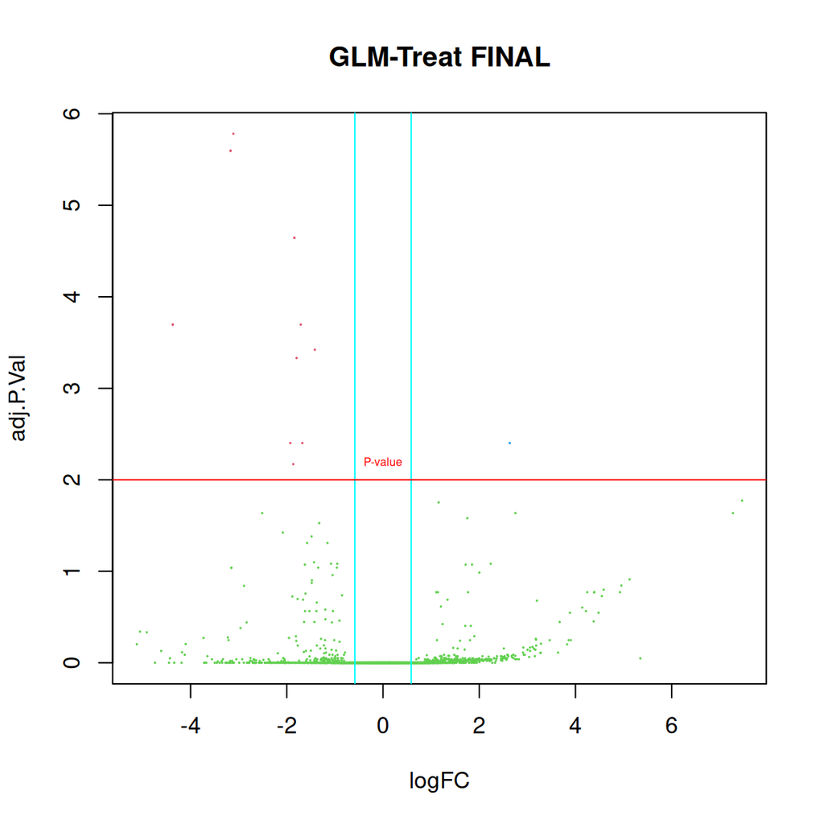

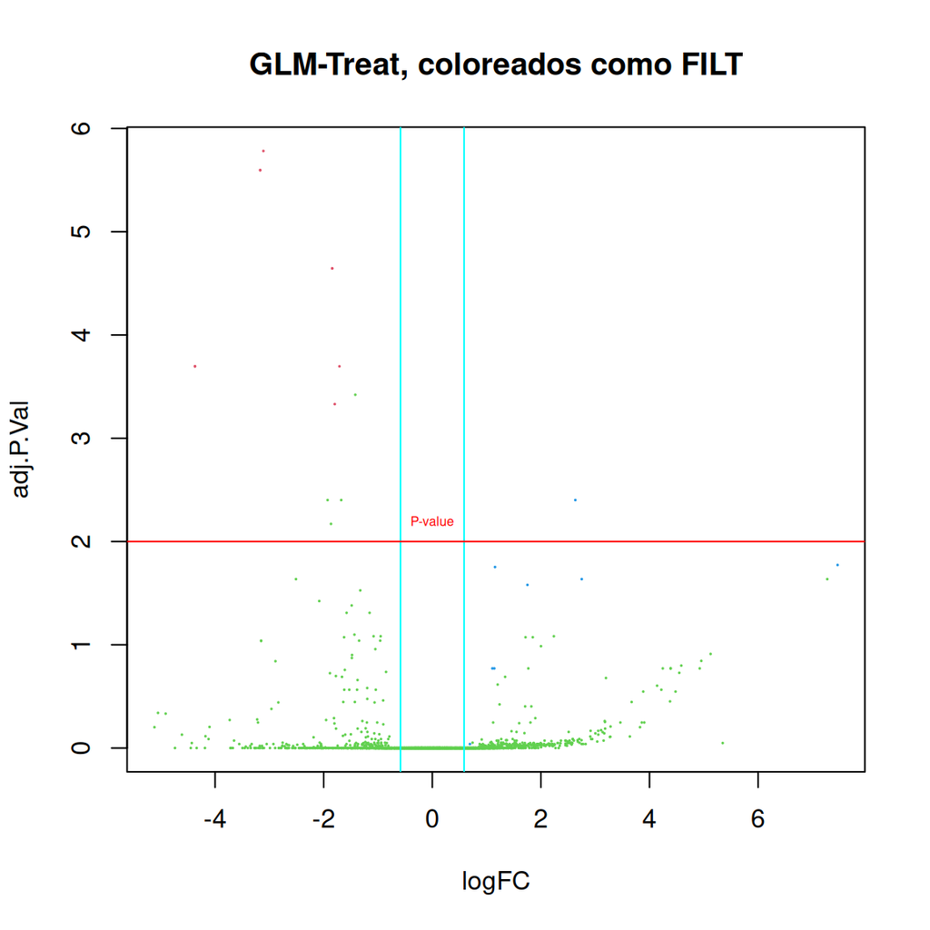

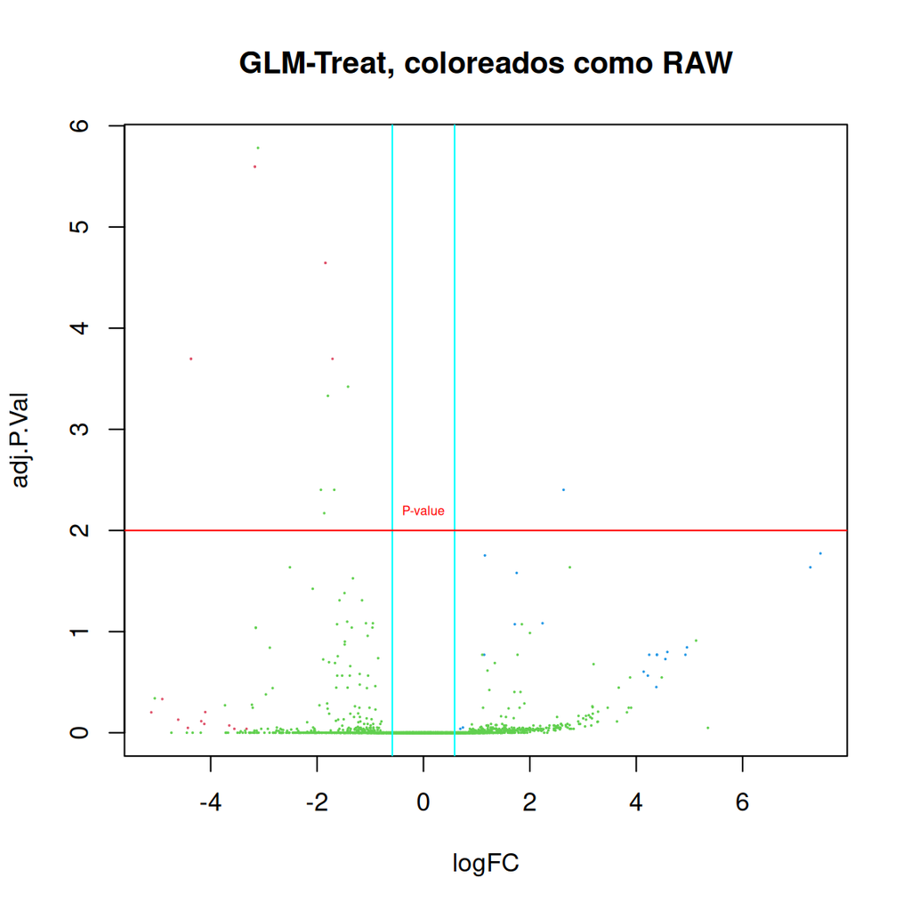

```r
# define -1, 0 and 1 for each gene ID;
# only the first column (first contrast) will be used
colours.norm <- dt.norm[rownames(table.to.save.glm_treat), 1] + 3
PlotMyVolcano(x = table.to.save.glm_treat$logFC,
              y = -log10(table.to.save.glm_treat$adj.P.Val),
              theCols = colours.norm,
              Xlegend = names(table.to.save.glm_treat[1]),
              Ylegend = names(table.to.save.glm_treat[5]),
              titleText = "GLM-Treat FINAL")

colours.norm <- dt.filt[rownames(table.to.save.glm_treat), 1] + 3
PlotMyVolcano(x = table.to.save.glm_treat$logFC,
              y = -log10(table.to.save.glm_treat$adj.P.Val),
              theCols = colours.norm,
              Xlegend = names(table.to.save.glm_treat[1]),
              Ylegend = names(table.to.save.glm_treat[5]),
              titleText = "GLM-Treat, coloreados como FILT")

colours.norm <- dt.raw[rownames(table.to.save.glm_treat), 1] + 3
PlotMyVolcano(x = table.to.save.glm_treat$logFC,
              y = -log10(table.to.save.glm_treat$adj.P.Val),
              theCols = colours.norm,
              Xlegend = names(table.to.save.glm_treat[1]),
              Ylegend = names(table.to.save.glm_treat[5]),
              titleText = "GLM-Treat, coloreados como RAW")
```

## Useless volcano plots

Otros volcanes ilustrativos, pero sin mayor interés para entender mejor en qué consisten los distintos valores que se han guardado para cada transcrito.

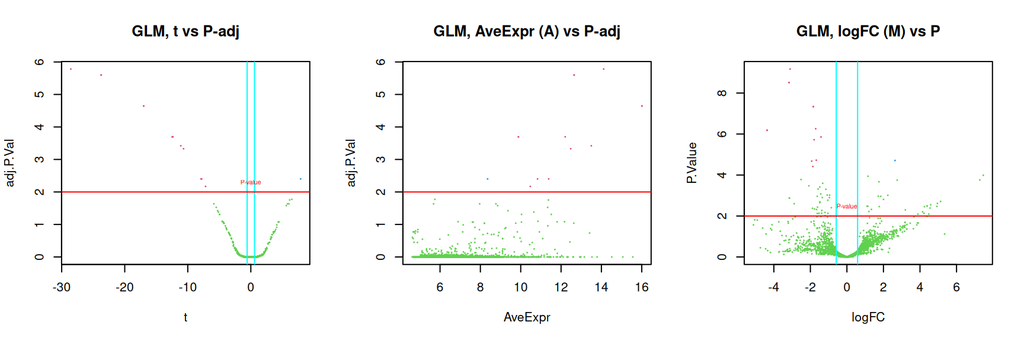

```r
par(mfrow = c(1,3))
# recuperamos los colores del grupo de interés
colours.norm <- dt.norm[rownames(table.to.save.glm_treat), ] + 3
PlotMyVolcano(x = table.to.save.glm_treat$t,
              y = -log10(table.to.save.glm_treat$adj.P.Val),
              theCols = colours.norm,
              Xlegend = names(table.to.save.glm_treat[3]),
              Ylegend = names(table.to.save.glm_treat[5]),
              titleText = "GLM, t vs P-adj")

PlotMyVolcano(x = table.to.save.glm_treat$AveExpr,
              y = -log10(table.to.save.glm_treat$adj.P.Val),
              theCols = colours.norm,
              Xlegend = names(table.to.save.glm_treat[2]),
              Ylegend = names(table.to.save.glm_treat[5]),
              titleText = "GLM, AveExpr (A) vs P-adj")

PlotMyVolcano(x = table.to.save.glm_treat$logFC,
              y = -log10(table.to.save.glm_treat$P.Value),
              theCols = colours.norm,
              Xlegend = names(table.to.save.glm_treat[1]),
              Ylegend = names(table.to.save.glm_treat[4]),
              titleText = "GLM, logFC (M) vs P")
```

## *P* frente a *P* ajustada

Por último, comparemos los histogramas de los datos guardados del GLM antes y después del ajuste de la *P*.

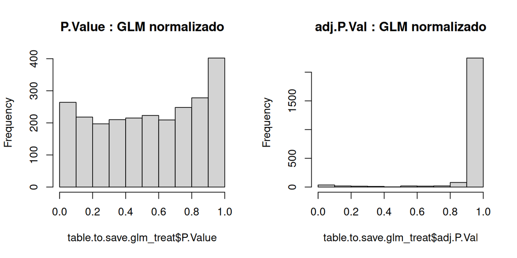

```r
par(mfrow = c(1,2))
hist(table.to.save.glm_treat$P.Value,
     main = paste(colnames(table.to.save.glm_treat)[4], ": GLM normalizado"))

hist(table.to.save.glm_treat$adj.P.Val,
     main = paste(colnames(table.to.save.glm_treat)[5], ": GLM normalizado"))
```

# Conclusiones de este trabajo

# References

Note that the reference csl style [can be changed](https://github.com/citation-style-language/styles) to a different style.

Chen, Yunshun, Aaron T L Lun, and Gordon K Smyth. 2016. “From Reads to Genes to Pathways: Differential Expression Analysis of RNA-Seq Experiments Using Rsubread and the edgeR Quasi-Likelihood Pipeline.” *F1000Res* 5: 1438. https://doi.org/10.12688/f1000research.8987.2.

# Additional readings

- [Efficient library loading](https://www.r-bloggers.com/an-efficient-way-to-install-and-load-r-packages/)
- [Differential expression analysis with edgeR](https://gist.github.com/jdblischak/11384914)
- [Basic differential expression: EdgeR exact test](https://morphoscape.wordpress.com/2020/09/01/exact-tests-and-plots-with-edger-basic-differential-expression-analysis/)
- [Differential expression analyses of RNA-seq experiments using quasi-likelihood methods (QLF)](http://www.statsci.org/smyth/pubs/QLedgeRPreprint.pdf)
- [Advanced differential expression using generalised linear models (GLM)](https://morphoscape.wordpress.com/2020/09/26/generalized-linear-models-and-plots-with-edger-advanced-differential-expression-analysis/)
- Bioinformatics Analysis of Omics Data with the [Shell, R](https://morphoscape.wordpress.com/2022/07/28/bioinformatics-analysis-of-omics-data-with-the-shell-r/) and [edgeR](https://morphoscape.wordpress.com/2022/08/09/downstream-bioinformatics-analysis-of-omics-data-with-edger/)
- RNA-seq analysis is easy as 1-2-3: [artículo de 2018](https://doi.org/10.12688/f1000research.9005.3) y [paquete RNAseq123](http://bioconductor.org/packages/release/workflows/html/RNAseq123.html) en Bioconductor.
- Varet et al. 2016 SARTools: A DESeq2- and EdgeR-Based R Pipeline for Comprehensive Differential Analysis of RNA-Seq Data. [*PLoS ONE* 11(6): e0157022](https://journals.plos.org/plosone/article?id=10.1371/journal.pone.0157022), DOI 10.1371/journal.pone.0157022

# Information about this session

```r
# T00 calculated in execute_wf.R
Tff <- proc.time() # final time
T_total <- Tff - T00
print("Tiempo empleado en la ejecución:")
print(T_total)
```

```
## [1] "Tiempo empleado en la ejecución:"
##    user  system elapsed
##  10.632   0.043  10.707
```

El tiempo de reloj empleado: **0.18 min**.

```r
cat("Variables in memory:\n")
ls()
cat("\n")
sessionInfo()
```

```
## Variables in memory:
##  [1] "allContrasts"             "allFiles"                 "ARGS"                     "C1"                       "CHARS_TO_REMOVE"
##  [6] "COL_NAMES"                "COL_NUMBER"               "colours.norm"             "COMP_DETAILS"             "COMPUTER"
## [11] "COND_FREQ"                "contr.matrix"             "CONTRASTS"                "CreateDir"                "CTRL"
## [16] "DANGER_bx"                "DATA_DIR"                 "degs.to.save.eB"          "design"                   "doPlot"
## [21] "dt.filt"                  "dt.norm"                  "dt.raw"                   "eB.filt.norm.status.p.fc" "eB.filt.status.p.fc"
## [26] "eB.status.p.fc"           "errMsg"                   "EXP_COLORS"               "EXP_CONDITIONS"           "EXP_FACTORS"
## [31] "EXPAND_bx"                "FC"                       "fileName"                 "FILT_TXT"                 "filt.degs"
## [36] "GetComputer"              "HOY"                      "i"                        "INTERACTIVE_SESSION"      "LoadExpressionData"
## [41] "loadRmd"                  "logFC"                    "MIN_CPM"                  "MIN_REPL"                 "msg"
## [46] "NORM_TXT"                 "norm.degs"                "NOTE_bx"                  "NUM_CONTRASTS"            "OK_bx"
## [51] "okMsg"                    "P"                        "pca_sum"                  "PKG_UPDATE"               "PlotGeneDensity"
## [56] "PlotMyPCA"                "PlotMyVolcano"            "PROJECT_NAME"             "RAW_TXT"                  "raw.degs"
## [61] "SaveTSV"                  "SOFT_NAME"                "SOURCE_DIR"               "T_total"                  "T00"
## [66] "table.to.save.glm_treat"  "Tff"                      "theContrast"              "tmp"                      "TREAT"
## [71] "UNIQ_FACTORS"             "v"                        "v.filt"                   "v.filt.fit.eB"            "v.filt.fit.treat"
## [76] "v.filt.norm"              "v.filt.norm.fit.eB"       "v.filt.norm.fit.treat"    "v.fit.eB"                 "v.fit.treat"
## [81] "venn.list"                "venn.matrix"              "VERBOSE_MODE"             "VERSION_BIOC"             "VERSION_CODE"
## [86] "VERSION_R"                "WARN_bx"                  "WD"                       "x"                        "x.cpm"
## [91] "x.filt"                   "x.filt.cpm"               "x.filt.lcpm"              "x.filt.norm"              "x.filt.norm.disp"
## [96] "x.filt.norm.lcpm"         "x.lcpm"                   "YO"
##
## R version 4.3.3 (2024-02-29)
## Platform: x86_64-pc-linux-gnu (64-bit)
## Running under: Ubuntu 24.04.1 LTS
##
## Matrix products: default
## BLAS:   /usr/lib/x86_64-linux-gnu/atlas/libblas.so.3.10.3
## LAPACK: /usr/lib/x86_64-linux-gnu/atlas/liblapack.so.3.10.3;  LAPACK version 3.11.0
##
## locale:
##  [1] LC_CTYPE=es_ES.UTF-8       LC_NUMERIC=C               LC_TIME=es_ES.UTF-8        LC_COLLATE=es_ES.UTF-8     LC_MONETARY=es_ES.UTF-8
##  [6] LC_MESSAGES=es_ES.UTF-8    LC_PAPER=es_ES.UTF-8       LC_NAME=C                  LC_ADDRESS=C               LC_TELEPHONE=C
## [11] LC_MEASUREMENT=es_ES.UTF-8 LC_IDENTIFICATION=C
##
## time zone: Europe/Madrid
## tzcode source: system (glibc)
##
## attached base packages:
## [1] grid      stats     graphics  grDevices utils     datasets  methods   base
##
## other attached packages:
##  [1] RColorBrewer_1.1-3   edgeR_4.0.16         limma_3.58.1         corrplot_0.94        psych_2.4.6.26       igraph_2.0.3         statmod_1.5.0
##  [8] DT_0.33              bibtex_0.5.1         markdown_1.13        rmarkdown_2.28       knitcitations_1.0.12 knitr_1.48           VennDiagram_1.7.3
## [15] futile.logger_1.4.3  gplots_3.1.3.1       ggvenn_0.1.10        reshape2_1.4.4       scales_1.3.0         ggpubr_0.6.0         lubridate_1.9.3
## [22] forcats_1.0.0        stringr_1.5.1        dplyr_1.1.4          purrr_1.0.2          readr_2.1.5          tidyr_1.3.1          tibble_3.2.1
## [29] tidyverse_2.0.0      ggplot2_3.5.1
##
## loaded via a namespace (and not attached):
##  [1] tidyselect_1.2.1     bitops_1.0-8         fastmap_1.2.0        digest_0.6.37        timechange_0.3.0     lifecycle_1.0.4      magrittr_2.0.3
##  [8] compiler_4.3.3       sass_0.4.9           rlang_1.1.4          tools_4.3.3          utf8_1.2.4           yaml_2.3.10          ggsignif_0.6.4
## [15] lambda.r_1.2.4       htmlwidgets_1.6.4    mnormt_2.1.1         plyr_1.8.9           xml2_1.3.6           abind_1.4-8          KernSmooth_2.23-22
## [22] withr_3.0.1          fansi_1.0.6          caTools_1.18.3       colorspace_2.1-1     gtools_3.9.5         cli_3.6.3            generics_0.1.3
## [29] rstudioapi_0.16.0    httr_1.4.7           tzdb_0.4.0           cachem_1.1.0         splines_4.3.3        parallel_4.3.3       formatR_1.14
## [36] BiocManager_1.30.25  vctrs_0.6.5          jsonlite_1.8.8       carData_3.0-5        car_3.1-2            hms_1.1.3            rstatix_0.7.2
## [43] crosstalk_1.2.1      locfit_1.5-9.10      jquerylib_0.1.4      glue_1.7.0           RefManageR_1.4.0     stringi_1.8.4        gtable_0.3.5
## [50] munsell_0.5.1        pillar_1.9.0         htmltools_0.5.8.1    R6_2.5.1             evaluate_1.0.0       lattice_0.22-5       highr_0.11
## [57] futile.options_1.0.1 backports_1.5.0      broom_1.0.6          bslib_0.8.0          Rcpp_1.0.13          nlme_3.1-164         xfun_0.47
## [64] pkgconfig_2.0.3
```